# 3.PCAforKeys

# Using Principal Component Analysis to compress the key points

## Loading the data

We load from the compiled, preformatted data saved earlier. We also define the random seed for repeatability.

```r
set.seed(56)
load("d.train.RData")
load("im.train.RData")
load("functions.viewing.RData")
ls()
```

```
##  [1] "d.key.mean"       "d.key.mean.all"   "d.train"
##  [4] "d.train.complete" "im.train"         "m.key.mean"
##  [7] "m.key.mean.all"   "m.mirrorKey"      "m.plotImage"
## [10] "m.plotKeypoints"
```

## Compute the PCA model on the training set

We compute the model on the subset of keys that have absolutely no missing.

- We use prcomp and not princomp, according to various recommandations : stability, etc ..
- we **do not** use the scale and center provided. We will manage centering manually and scaling does not appear necessary.

```r
m.key.pca <- prcomp(~ . , data=d.train[d.train.complete,] - m.key.mean, retx = FALSE,
                      scale. = FALSE, center=FALSE )

summary(m.key.pca)
```

```
## Importance of components:
##                             PC1     PC2     PC3      PC4     PC5     PC6
## Standard deviation     102.6607 67.9559 67.0113 33.52440 7.85145 6.71946
## Proportion of Variance   0.5025  0.2202  0.2141  0.05359 0.00294 0.00215
## Cumulative Proportion    0.5025  0.7227  0.9368  0.99040 0.99334 0.99550
##                            PC7     PC8     PC9    PC10    PC11    PC12
## Standard deviation     4.60471 4.25235 3.49870 3.01318 2.60256 2.47835
## Proportion of Variance 0.00101 0.00086 0.00058 0.00043 0.00032 0.00029
## Cumulative Proportion  0.99651 0.99737 0.99795 0.99838 0.99871 0.99900
##                           PC13    PC14    PC15    PC16    PC17    PC18
## Standard deviation     2.13912 1.87190 1.74131 1.26152 1.22381 1.21354
## Proportion of Variance 0.00022 0.00017 0.00014 0.00008 0.00007 0.00007
## Cumulative Proportion  0.99922 0.99939 0.99953 0.99961 0.99968 0.99975
##                           PC19    PC20    PC21    PC22    PC23    PC24
## Standard deviation     1.06156 0.94696 0.81398 0.67472 0.63898 0.62774
## Proportion of Variance 0.00005 0.00004 0.00003 0.00002 0.00002 0.00002
## Cumulative Proportion  0.99980 0.99984 0.99988 0.99990 0.99992 0.99994
##                           PC25    PC26    PC27    PC28    PC29   PC30
## Standard deviation     0.60516 0.52324 0.48253 0.47050 0.41599 0.2739
## Proportion of Variance 0.00002 0.00001 0.00001 0.00001 0.00001 0.0000
## Cumulative Proportion  0.99995 0.99997 0.99998 0.99999 1.00000 1.0000
```

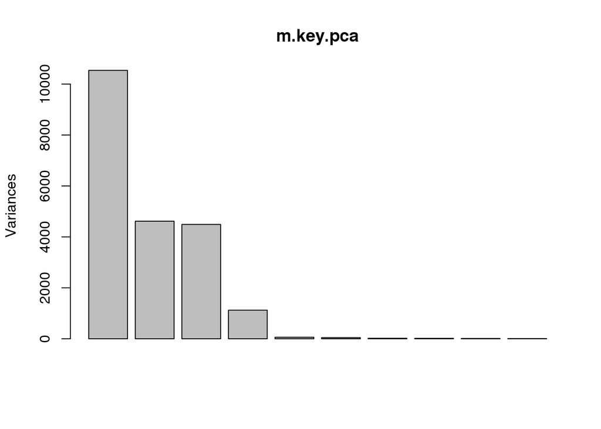

```r
plot(m.key.pca)
```

## Creating the transcoding functions

The function **m.key.pca.predict()** takes a key set, and retun a set of 30 PC.

Inversely, the function **m.key.pca.reconstruct()** takes a set of 30 PC and return the 30 keys.

The function **m.key.pca.truncate()** truncates an existing key, by converting back and forth from keys to PCS to keys while keeping only a few PCs. The keep parameter defines how many we keep.

```r
m.key.pca.predict <- function (key) {
  predict(m.key.pca, newdata = key - m.key.mean)
  }


m.key.pca.reconstruct <- function(pcs) {
  (pcs %*% t(m.key.pca$rotation)) + m.key.mean
}

m.key.pca.truncate <- function(key, keep=30) {
  pcs <- m.key.pca.predict(key)
  if(keep<30) {
    pcs[,(keep+1):30] <- 0
  }
  return (m.key.pca.reconstruct(pcs))
}
```

## Testing the transcoding

### Transcoding real records, no truncation

First, we test with some real keys from the training set, with no truncation. We transcode back and forth, and check the maximum absolute value for the difference.

```r
deltas <- matrix(0,10,1)
for(i in 1:10){
  k <- sample(d.train.complete, 1)
  kk <- m.key.pca.truncate(d.train[k,])
  deltas[i] = max(abs(d.train[k,]-kk))
}

deltas
```

```
##               [,1]
##  [1,] 7.105427e-15
##  [2,] 3.552714e-15
##  [3,] 7.105427e-15
##  [4,] 1.421085e-14
##  [5,] 7.105427e-15
##  [6,] 7.105427e-15
##  [7,] 7.105427e-15
##  [8,] 3.552714e-15
##  [9,] 5.329071e-15
## [10,] 1.421085e-14
```

Looks pretty good, if the above table shows only very small numbers. The largest absolute error was 1.421085510^{-14}

### Transcoding real records, but truncating

We are going to gradually truncate less and less (keep more and more) of the record.

```r
deltas <- matrix(0,30,1)
k <- sample(d.train.complete, 1)
for(i in 1:30){
  kk <- m.key.pca.truncate(d.train[k,], i)
  deltas[i] = max(abs(d.train[k,]-kk))
}

deltas
```

```
##               [,1]
##  [1,] 6.586815e+00
##  [2,] 6.271624e+00
##  [3,] 6.227715e+00
##  [4,] 6.212568e+00
##  [5,] 6.147068e+00
##  [6,] 4.168013e+00
##  [7,] 4.166402e+00
##  [8,] 3.723924e+00
##  [9,] 2.733444e+00
## [10,] 2.780974e+00
## [11,] 1.693435e+00
## [12,] 1.700895e+00
## [13,] 1.670304e+00
## [14,] 1.654824e+00
```

[output cut: 16 more lines]

```r
rm(kk,k,deltas)
```

Basically, we need at least 5-6 PC to reconstruct correctly … This is consistent with the variance analysis of the model above.

How does it look graphically ? (the closer to the red, the more we keep)

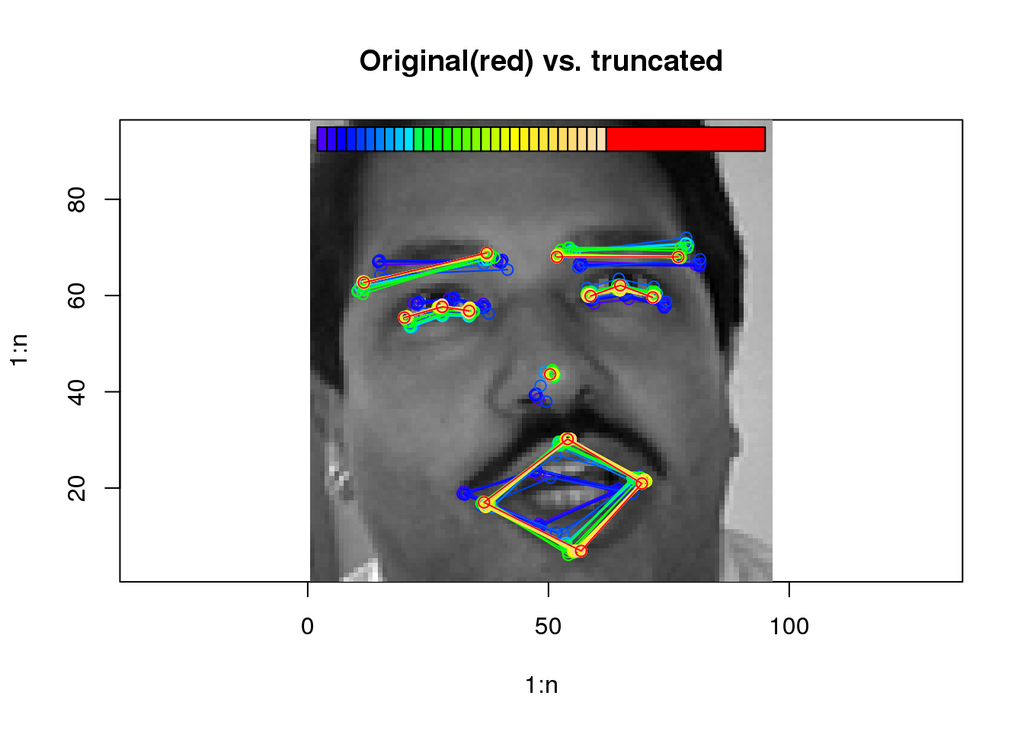

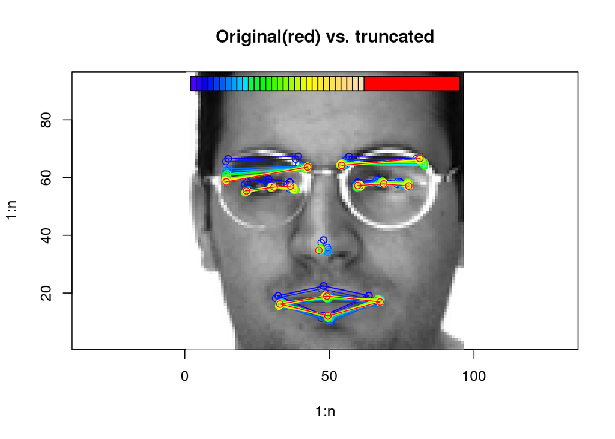

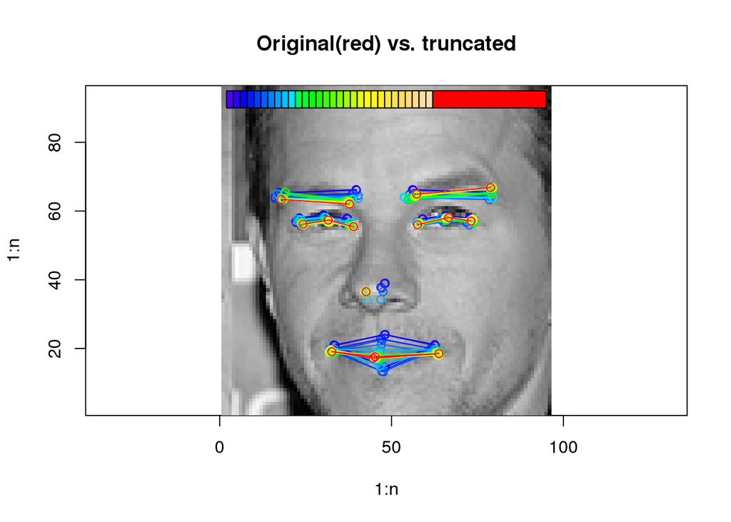

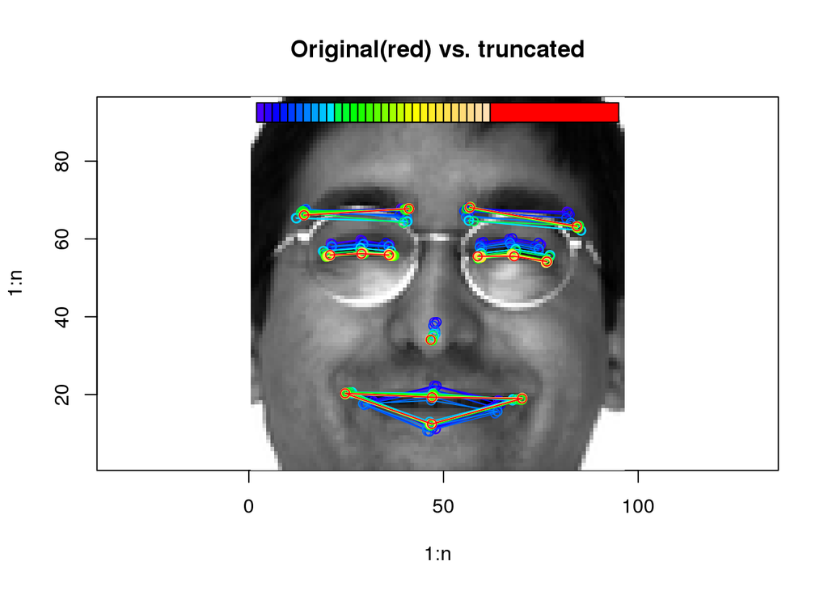

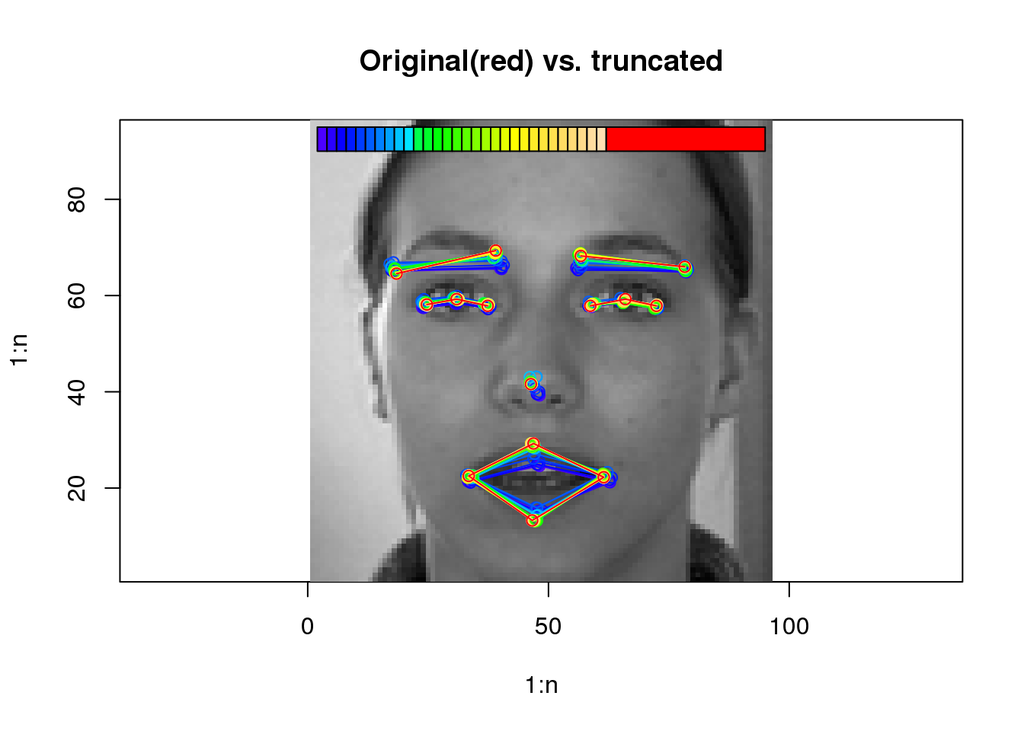

```r
for (j in 1:5) { # draw 5 pictures
  k <- sample(d.train.complete, 1)
  m.plotImage(im.train[k, ])
  for (i in 1:30) {
    r <- topo.colors(30)
    m.plotKeypoints(m.key.pca.truncate(d.train[k, ], i), col = r[i])
    rect(
      xleft = (i * 2) ,
      ybottom = 90 ,
      xright = (i * 2 + 2),
      ytop = 95,
      col = r[i]
    )
  }
  rect(
    xleft = 62 ,
    ybottom = 90 ,
    xright = 95,
    ytop = 95,
    col = "red"
  )
  m.plotKeypoints(d.train[k, ], col = "red")
  title(main = "Original(red) vs. truncated")
}
```

```r
rm(i,j,k,r)
```

## Cleaning and saving

We save what was added.

```r
save(m.key.pca,m.key.pca.truncate,m.key.pca.reconstruct, m.key.pca.predict, file = "m.key.pca.RData")
ls()
```

```
##  [1] "d.key.mean"            "d.key.mean.all"
##  [3] "d.train"               "d.train.complete"
##  [5] "im.train"              "m.key.mean"
##  [7] "m.key.mean.all"        "m.key.pca"
##  [9] "m.key.pca.predict"     "m.key.pca.reconstruct"
## [11] "m.key.pca.truncate"    "m.mirrorKey"
## [13] "m.plotImage"           "m.plotKeypoints"
```

*This file was compiled on Mon Jun 6 08:09:49 2016*